# BlogEntry2

Zachary Palmore

5/18/2021

## Homoscedasticity

What is homoscedasticity? To me, it is a fancy word to describe how data has the same variance over its residuals. In other words, it is the state of relatively constant variance over the data’s distribution. In this week’s post we are going to take a look at what exactly that means and what it might look like. As usual, we start with our data.

```r
library(dplyr)
plants <- read.csv("https://docs.google.com/spreadsheets/d/e/2PACX-1vRVUsZrUEFrV0_2OQSCIn_JHCgs-ylPlFyowhr63XTCyAebIpVp7Dzq4Os_ARfm0yeEsrkenL_he4K4/pub?gid=0&single=true&output=csv", header = TRUE, sep = ",")
# Select the columns we want
grow <- plants %>%
  select(PlantID, Day, Hours, PlantWidth, PlantHeight)
grow$PlantWidth <- as.numeric(grow$PlantWidth)
grow$PlantHeight <- as.numeric(grow$PlantHeight)
grow$PlantID <- as.factor(grow$PlantID)
grow[is.na(grow)] <- .5
head(grow)
```

```
##   PlantID Day Hours PlantWidth PlantHeight
## 1    None   0     0        0.5         0.5
## 2    None   1    24        0.5         0.5
## 3    None   2    48        0.5         0.5
## 4    None   3    72        0.5         0.5
## 5    None   4    96        0.5         0.5
## 6    None   5   120        0.5         0.5
```

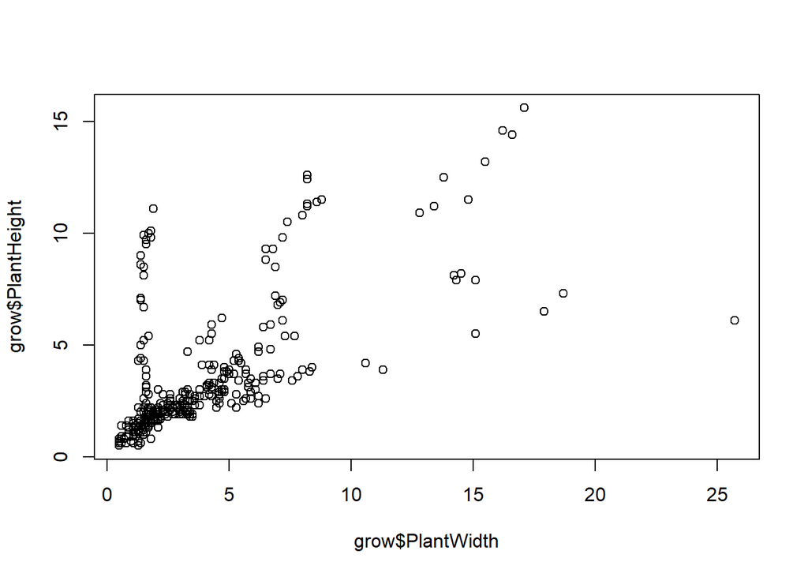

```r
plot(grow$PlantWidth, grow$PlantHeight)
```

For each plant, the data seems to spread about in their own direction. This makes sense, since, as we mentioned, they are completely different species and growth cycles. Picking the model then becomes difficult since none seem to follow the same pattern. The closest patterns might be linear so we apply linear regression.

```r
grow.lm <- lm(grow$PlantHeight ~ grow$PlantWidth)
summary(grow.lm)
```

```
##
## Call:
## lm(formula = grow$PlantHeight ~ grow$PlantWidth)
##
## Residuals:
##      Min       1Q   Median       3Q      Max
## -10.8387  -0.5252  -0.5252  -0.0514   9.1907
##
## Coefficients:
##                 Estimate Std. Error t value Pr(>|t|)
## (Intercept)      0.70948    0.09639   7.361 6.58e-13 ***
## grow$PlantWidth  0.63149    0.02380  26.535  < 2e-16 ***
## ---
## Signif. codes:  0 '***' 0.001 '**' 0.01 '*' 0.05 '.' 0.1 ' ' 1
##
## Residual standard error: 1.775 on 559 degrees of freedom
## Multiple R-squared:  0.5574, Adjusted R-squared:  0.5567
## F-statistic: 704.1 on 1 and 559 DF,  p-value: < 2.2e-16
```

Perhaps surprisingly, this works moderately well, based solely on the $r^2$ and $p$ values provided in the summary. But to assess homoscedasticity we need to look at a diagnostic plot. We plot all the model’s diagnostic plots for reference. The one we are most interested in is the plot of Residuals vs fitted values.

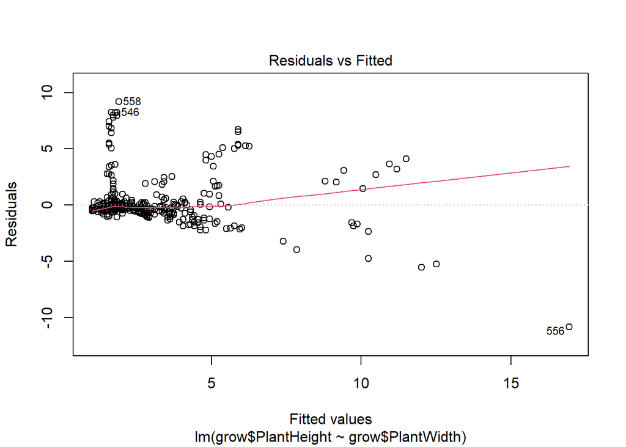

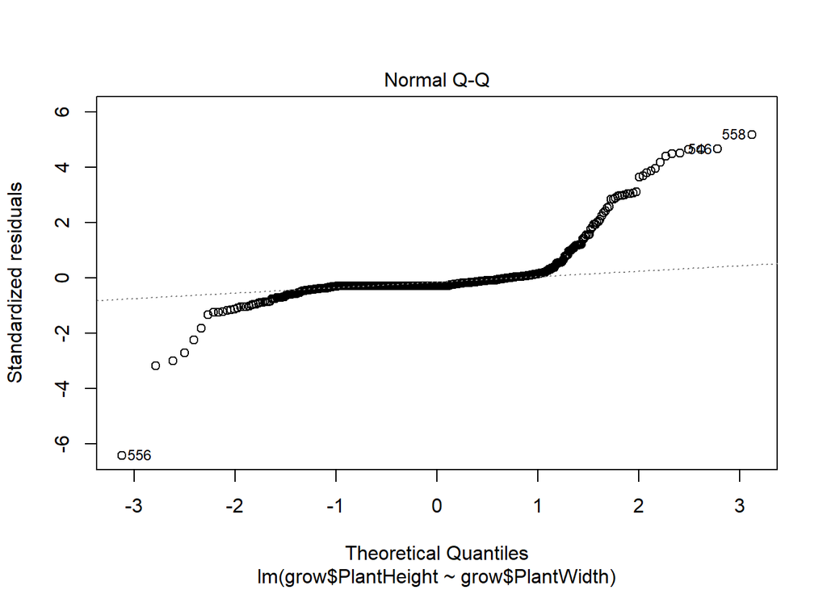

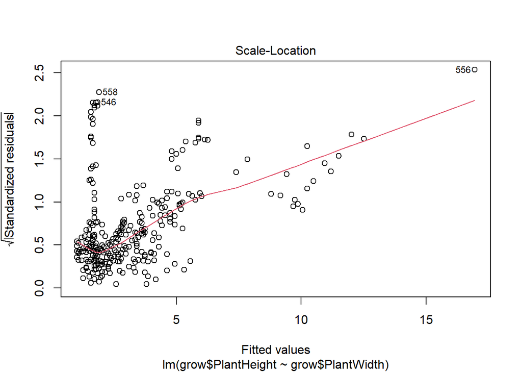

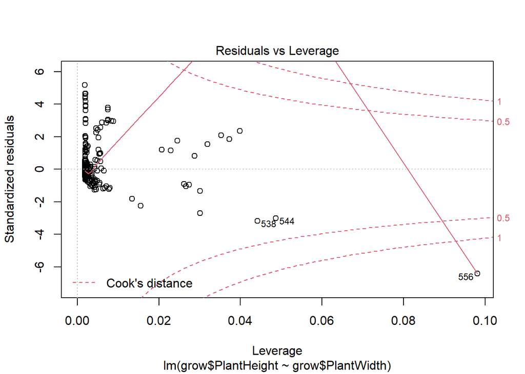

```r
plot(grow.lm)
```

Ideal conditions would show the red line as flat against the dotted line with the points scattered evenly on both above and below the line. In this case, our residuals are concentrated towards the lower end of our fitted values and as they increase, so too does the variance. For our purposes, this minor deviation from the dotted line should not cause much of an issue. We are already aware that there are multiple species all clustered together within this data.

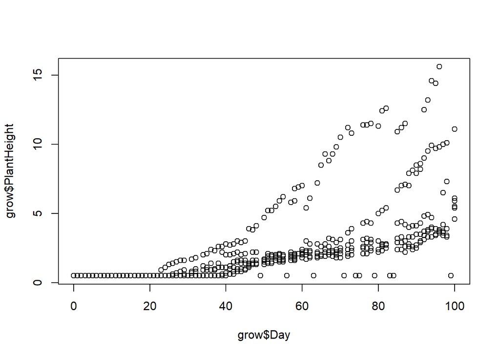

```r
plot(grow$Day, grow$PlantHeight)
```

```r
grow.lm <- lm(grow$Day ~ grow$PlantWidth)
summary(grow.lm)
```

```
##
## Call:
## lm(formula = grow$Day ~ grow$PlantWidth)
##
## Residuals:
##     Min      1Q  Median      3Q     Max
## -67.224 -17.430  -1.582  17.523  54.788
##
## Coefficients:
##                 Estimate Std. Error t value Pr(>|t|)
## (Intercept)      41.7717     1.1877   35.17   <2e-16 ***
## grow$PlantWidth   4.8814     0.2932   16.65   <2e-16 ***
## ---
## Signif. codes:  0 '***' 0.001 '**' 0.01 '*' 0.05 '.' 0.1 ' ' 1
##
## Residual standard error: 21.88 on 559 degrees of freedom
## Multiple R-squared:  0.3314, Adjusted R-squared:  0.3302
## F-statistic: 277.1 on 1 and 559 DF,  p-value: < 2.2e-16
```

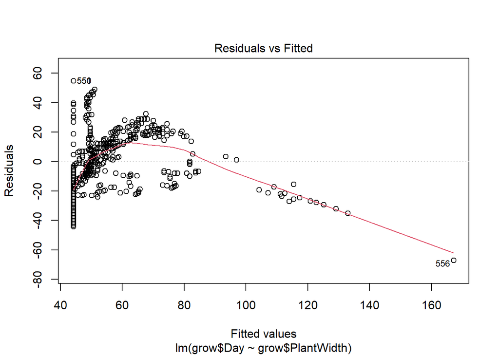

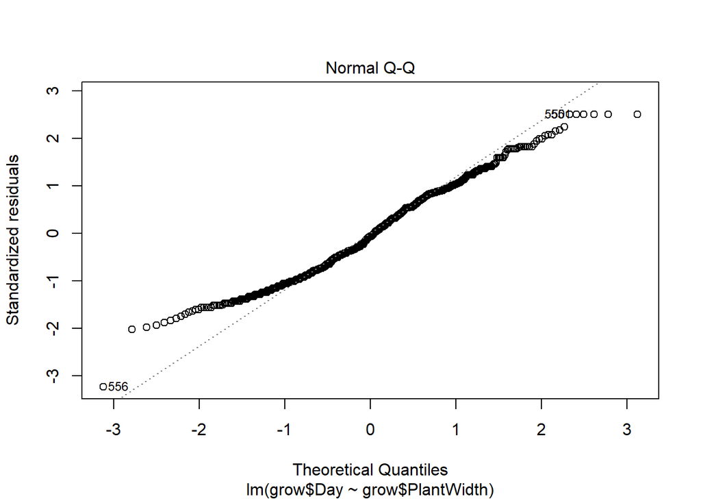

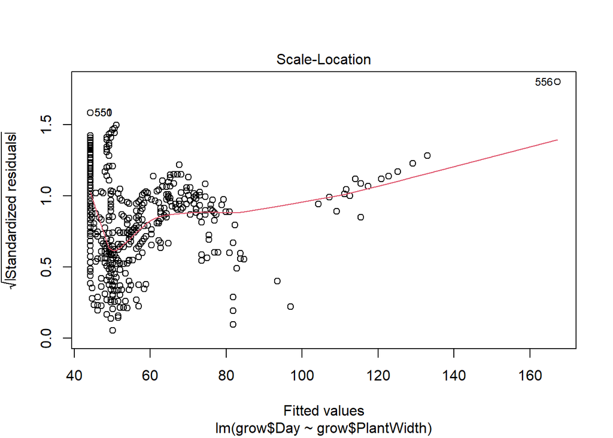

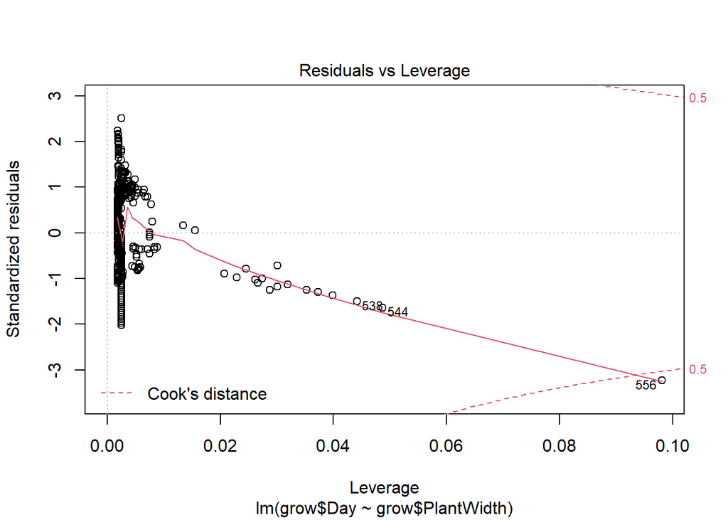

```r
plot(grow.lm)
```

With these variables we get a different result. As the number of days increases the general trend is that the plant height also increases but each at a different rate. This is consistent with our previous findings with plant height and plant width. This time, our residuals vs fitted plot is a bit off.

As we travel from left to right on the plot of residuals vs fitted values the red line first increases sharply, tapers itself slowly, and drops steadily until it is well below the dotted line at zero. This zero line indicates zero variance and in this case, the variance is too great to be considered homoscedastic. Instead, we would say this data exhibits heteroscedasticity.

Another example might be the most interesting yet since it is rarely seen in linear regression. We have two variables that we know to be equivalent but that contain different units. They are the day and hours variables. If we were to create a diagnostic plot of these two, what do you think would happen? We repeat the process to find out.

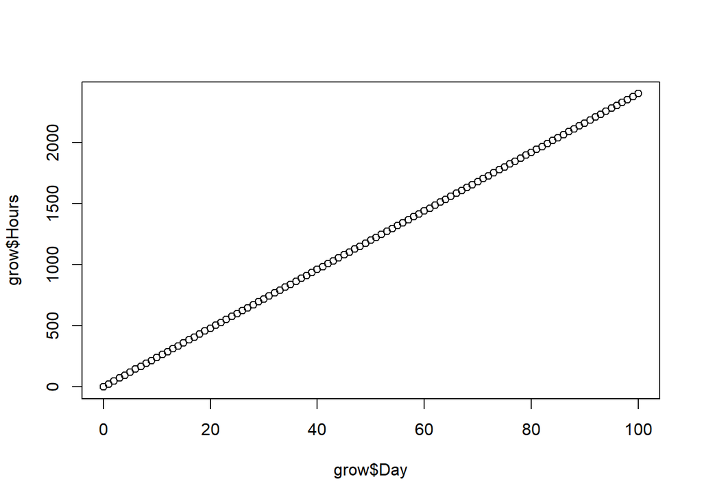

```r
plot(grow$Day, grow$Hours)
```

```r
grow.lm <- lm(grow$Day ~ grow$Hours)
summary(grow.lm)
```

```
##
## Call:
## lm(formula = grow$Day ~ grow$Hours)
##
## Residuals:
##        Min         1Q     Median         3Q        Max
## -3.681e-13 -1.380e-15 -4.100e-16  5.900e-16  6.356e-13
##
## Coefficients:
##               Estimate Std. Error    t value Pr(>|t|)
## (Intercept) -1.920e-14  2.974e-15 -6.456e+00 2.33e-10 ***
## grow$Hours   4.167e-02  2.051e-18  2.032e+16  < 2e-16 ***
## ---
## Signif. codes:  0 '***' 0.001 '**' 0.01 '*' 0.05 '.' 0.1 ' ' 1
##
## Residual standard error: 3.113e-14 on 559 degrees of freedom
## Multiple R-squared:      1,  Adjusted R-squared:      1
## F-statistic: 4.129e+32 on 1 and 559 DF,  p-value: < 2.2e-16
```

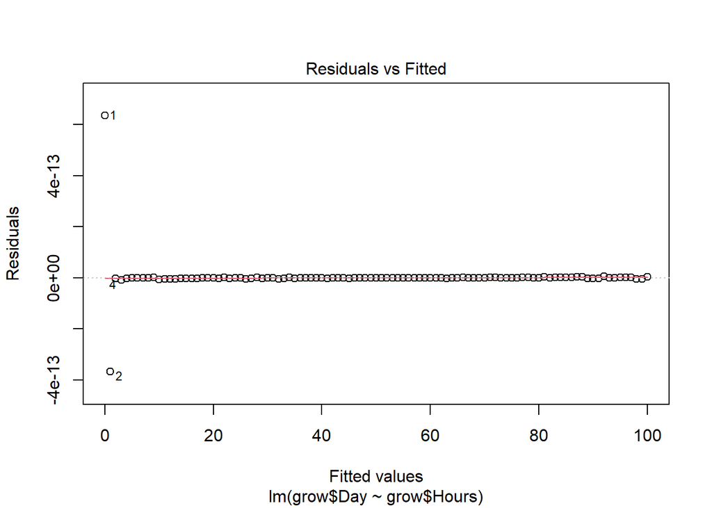

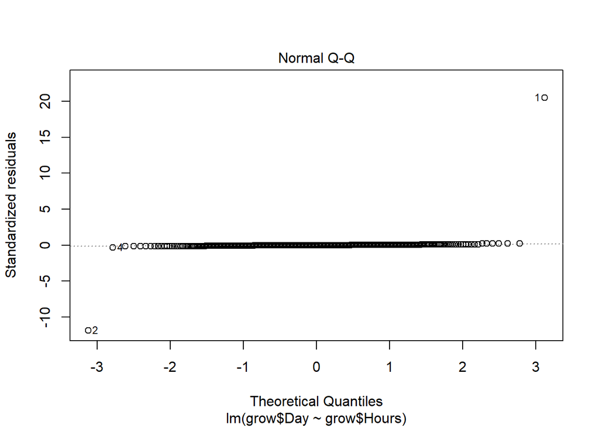

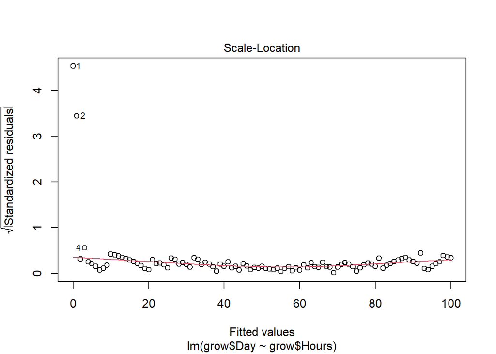

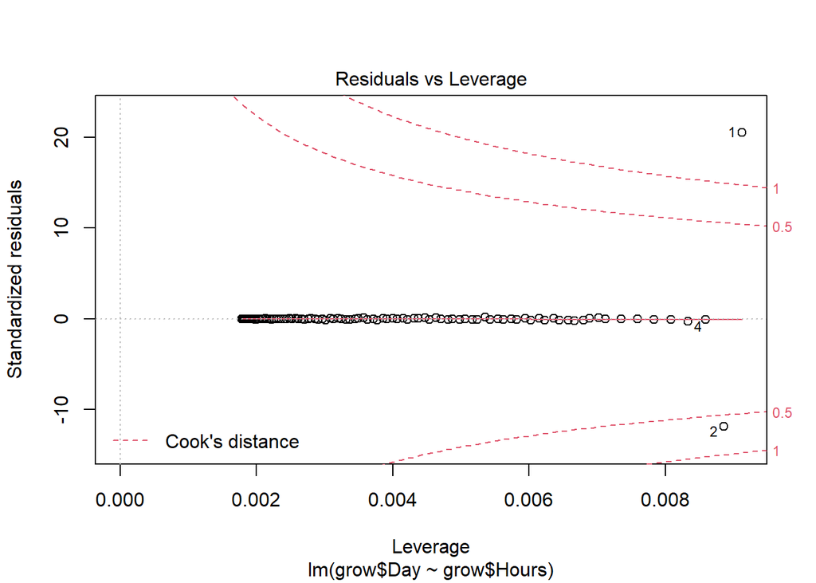

```r
plot(grow.lm)
```

The result is a flat line of points across the zero variance line. This seems to tell us there is constant variance in the residuals over the fitted values because there is no variance in the variables. If we think about this in terms of unit conversion, the plot makes sense. The number of days can be used to find the number of hours by simply multiplying the day by 24, since there are 24 hours in a day. They are said to be completely co-dependent.